# Assignment IV

Erika Lin

February 27, 2019

> Please submit your answers by 5.59 pm Monday March 4, 2019

## Question 1: Prediction using Logistic Regression

We are going to perform perdiction on a voting dataset (files->assignments->assignment_4). The dataset contains the party affliation of 435 congressional members along with voting record on 16 issues that were put to vote in a single year. The party affliation is indicated as a binary variable as a 1 if the congress-person was a member of the ‘A’ party and 0 otherwise. The vote is indicated as 1 (if the member voted yes) and 0 (if ithe member voted no).

1. You will notice that the class-split is fairly even in the dataset.

0 : 168 members 1 : 267 members

Using caret, create a rough 80-20 split of the dataset into training and testing. In other words, 80% of the data should comprise the training dataset and 20% of the data should comprise the testing dataset. Ensure that the class membership is even (in other words, the proportion of 1 and 0 in both training and testing should be the approximately the same)

NOTE: Set the seed to 476

```r
# Insert your code below
rm(list=ls())
library(plyr)
library(dplyr)
library(lattice)
library(ggplot2)
library(caret)

vote <- read.csv("data_votes.csv",header=TRUE) %>%
  mutate_if(is.numeric, as.factor)

summary(vote)
```

```
##  party_A handicapped_infants water_project_cost_sharing
##  0:168   0:248               0:240
##  1:267   1:187               1:195
##  adoption_of_bufget_resolution physician_fee_freeze el_salvador_aid
##  0:182                         0:258                0:223
##  1:253                         1:177                1:212
##  religious_group_in_schools anti_satellite_test_ban nicaragua_aid
##  0:163                      0:196                   0:193
##  1:272                      1:239                   1:242
##  mx_missile immigration syn_coorp_cutback education_spending
##  0:228      0:219       0:285             0:264
##  1:207      1:216       1:150             1:171
##  superfund_right_to_sue crime   duty_free_exports export_act_sa
##  0:226                  0:187   0:261             0:166
##  1:209                  1:248   1:174             1:269
```

```r
set.seed(476) #set seed to 476

#Create train dataset 80% split, create test dataset 20% split
split <- createDataPartition(vote$party_A, p=0.8, list=FALSE, times = 1)
train <- vote[split,]
test <- vote[-split,]
head(train)
```

```
##   party_A handicapped_infants water_project_cost_sharing
## 1       1                   1                          0
## 2       1                   1                          0
## 3       1                   1                          0
## 4       1                   1                          0
## 5       1                   1                          0
## 8       1                   0                          0
##   adoption_of_bufget_resolution physician_fee_freeze el_salvador_aid
## 1                             1                    0               0
## 2                             1                    0               0
## 3                             1                    0               0
## 4                             1                    0               0
## 5                             1                    0               0
## 8                             1                    0               0
##   religious_group_in_schools anti_satellite_test_ban nicaragua_aid
```

[output cut: 20 more lines]

```r
head(test)
```

```
##    party_A handicapped_infants water_project_cost_sharing
## 6        1                   0                          0
## 7        1                   0                          0
## 22       1                   1                          0
## 26       1                   1                          0
## 37       1                   1                          0
## 41       1                   0                          0
##    adoption_of_bufget_resolution physician_fee_freeze el_salvador_aid
## 6                              1                    0               0
## 7                              1                    0               0
## 22                             1                    0               0
## 26                             1                    0               0
## 37                             1                    0               0
## 41                             0                    0               0
##    religious_group_in_schools anti_satellite_test_ban nicaragua_aid
```

[output cut: 20 more lines]

```r
summary(as.factor(train$party_A))
```

```
##   0   1
## 135 214
```

```r
summary(as.factor(test$party_A))
```

```
##  0  1
## 33 53
```

2. Perform a logistic regression (using glm) on the training dataset and perform a prediction on the test dataset.

```r
# Insert your code below

#Logistic regression on the training dataset
train.log <- glm(formula = party_A~., data=train, family ="binomial")
summary(train.log)
```

```
##
## Call:
## glm(formula = party_A ~ ., family = "binomial", data = train)
##
## Deviance Residuals:
##      Min        1Q    Median        3Q       Max
## -2.50447  -0.00922   0.00227   0.03336   2.53536
##
## Coefficients:
##                                Estimate Std. Error z value Pr(>|z|)
## (Intercept)                     -1.3665     1.4389  -0.950 0.342271
## handicapped_infants1             0.8535     1.1789   0.724 0.469056
## water_project_cost_sharing1      2.2776     1.3538   1.682 0.092494 .
## adoption_of_bufget_resolution1   5.2391     1.4789   3.543 0.000396 ***
## physician_fee_freeze1          -10.3548     2.4225  -4.274 1.92e-05 ***
## el_salvador_aid1                -0.1973     2.4615  -0.080 0.936124
## religious_group_in_schools1      0.5167     1.5101   0.342 0.732219
## anti_satellite_test_ban1         0.1184     1.6612   0.071 0.943166
## nicaragua_aid1                  -0.5569     2.0170  -0.276 0.782487
## mx_missile1                      3.1484     1.5380   2.047 0.040644 *
## immigration1                    -2.0112     1.2426  -1.619 0.105554
## syn_coorp_cutback1               5.7163     1.8020   3.172 0.001513 **
## education_spending1             -0.5277     1.1996  -0.440 0.660053
## superfund_right_to_sue1          1.8777     1.5557   1.207 0.227447
## crime1                           1.1626     1.2597   0.923 0.356066
## duty_free_exports1               2.3547     1.3106   1.797 0.072402 .
## export_act_sa1                  -2.2970     1.4037  -1.636 0.101745
## ---
## Signif. codes:  0 '***' 0.001 '**' 0.01 '*' 0.05 '.' 0.1 ' ' 1
##
## (Dispersion parameter for binomial family taken to be 1)
##
##     Null deviance: 465.778  on 348  degrees of freedom
## Residual deviance:  39.825  on 332  degrees of freedom
## AIC: 73.825
##
## Number of Fisher Scoring iterations: 9
```

```r
#Prediction on the test dataset
test$pred <- predict.glm(train.log, newdata=test, type = "response")
```

3. Fill the confusion matrix below using your predictions. Consider outcome 1 as being “positive” and a probability cutoff of 0.5 (i.e. if probability >= 0.5, assign the label 1).

```r
# Insert your code below

test$pred <- ifelse(test$pred >=0.5,1,0)

class(test$party_A)
```

```
## [1] "factor"
```

```r
class(test$pred)
```

```
## [1] "numeric"
```

```r
#TP
tp <- test %>%
  filter(party_A ==1 & pred==1)%>%
  nrow()

#FP
fp <- test %>%
  filter(party_A == 0 & pred==1)%>%
  nrow()

#FN
fn <- test %>%
  filter (party_A==1 & pred==0) %>%
  nrow()

#TN
tn <- test %>%
  filter(party_A ==0 & pred == 0)%>%
  nrow()
```

| Table | Actual_positive | Actual_negative |
| --- | --- | --- |
| Pred_positive | 50 | 0 |
| Pred_negative | 3 | 33 |

4. Calculate the following: Sensitivity, Specificity, Positive Predictive Value, Negative Predictive Value, False Positive Rate, and Accuracy.

```r
# Insert code below
#Sensitivity
tp/(tp+fn)
```

```
## [1] 0.9433962
```

```r
#Specificity
tn/(tn+fp)
```

```
## [1] 1
```

```r
#Positive Predictive Value
tp/(tp+fp)
```

```
## [1] 1
```

```r
#Negative Predictive Value
tn/(tn+fn)
```

```
## [1] 0.9166667
```

```r
#False Positive Rate (1-specificity)
1 - (tn/(tn+fp))
```

```
## [1] 0
```

```r
#Accuracy
(tn+tp)/(tp+tn+fp+fn)
```

```
## [1] 0.9651163
```

5. Calculate AUC (with 95% CI) using predicted probabilities

```r
# Insert code below

library(pROC)
#Creat prediction
test$pred <- predict.glm(train.log, newdata=test, type = "response")

prediction <- roc(response = test$party_A, predictor = test$pred, direction = "<")

#Calculate AUC with 95% CI on test dataset
auc_calc_test <- auc(prediction)
cat("AUC:", auc_calc_test, "\n")
```

```
## AUC: 0.9914237
```

```r
ci_auc_calc_test <- ci.auc(prediction)
cat("95% CI:", ci_auc_calc_test, "\n")
```

```
## 95% CI: 0.9761996 0.9914237 1
```

## Question 2: Cross-validation

Write a program that will perform 3-fold cross-validation (using the caret package) on the above train dataset. Calculate AUC (with 95% CI) on the test (train)? dataset.

NOTE : Set your seed as 156

```r
# Insert code here
library(plyr)
library(dplyr)
library(lubridate)
library(lattice)
library(ggplot2)
library(caret)
library(pROC)

data(train)
set.seed(156) #set seed to 156

#3-fold cross-validation
#train_folds <- createFolds(train$party_A, k=3, list = TRUE)
#head(train_folds)

#Training using GLM (3-fold cross-validation)
training_params <- trainControl(method="cv", number=3)
train.glm <- train(as.factor(party_A)~.,data=train,method="glm", trControl = training_params)

#Prediction using caret
yhat_glm <- predict(train.glm, newdata=test, type="prob")

#Create a prediction object
prediction2 <- roc(predictor = yhat_glm[,2], response=test$party_A, direction = "<")

#Calculate AUC with 95% CI on train dataset
auc_calc_test2 <- auc(prediction2)
cat("AUC:", auc_calc_test2, "\n")
```

```
## AUC: 0.9914237
```

```r
ci_auc_calc_test2 <- ci.auc(prediction2)
cat("95$ CI:", ci_auc_calc_test2, "\n")
```

```
## 95$ CI: 0.9761996 0.9914237 1
```

## Question 3: Hierarchical clustering

We are going to use the USArrests dataset. Load this using the following command

```r
d.in <- data.frame(USArrests)
head(d.in)
```

```
##            Murder Assault UrbanPop Rape
## Alabama      13.2     236       58 21.2
## Alaska       10.0     263       48 44.5
## Arizona       8.1     294       80 31.0
## Arkansas      8.8     190       50 19.5
## California    9.0     276       91 40.6
## Colorado      7.9     204       78 38.7
```

1. Perform hierarchical clustering using average linkage and Euclidean distance. Write the code and show the plots below.

Ans.

```r
# Insert code here

#Euclidean distance
dist_in <- dist(d.in, method = "euclidean")

#Visualize matrix
temp_matrix <- as.matrix(dist_in)
print(temp_matrix[1:6,1:6])
```

```
##             Alabama   Alaska   Arizona  Arkansas California Colorado
## Alabama     0.00000 37.17701  63.00833  46.92814   55.52477 41.93256
## Alaska     37.17701  0.00000  46.59249  77.19741   45.10222 66.47594
## Arizona    63.00833 46.59249   0.00000 108.85192   23.19418 90.35115
## Arkansas   46.92814 77.19741 108.85192   0.00000   97.58202 36.73486
## California 55.52477 45.10222  23.19418  97.58202    0.00000 73.19713
## Colorado   41.93256 66.47594  90.35115  36.73486   73.19713  0.00000
```

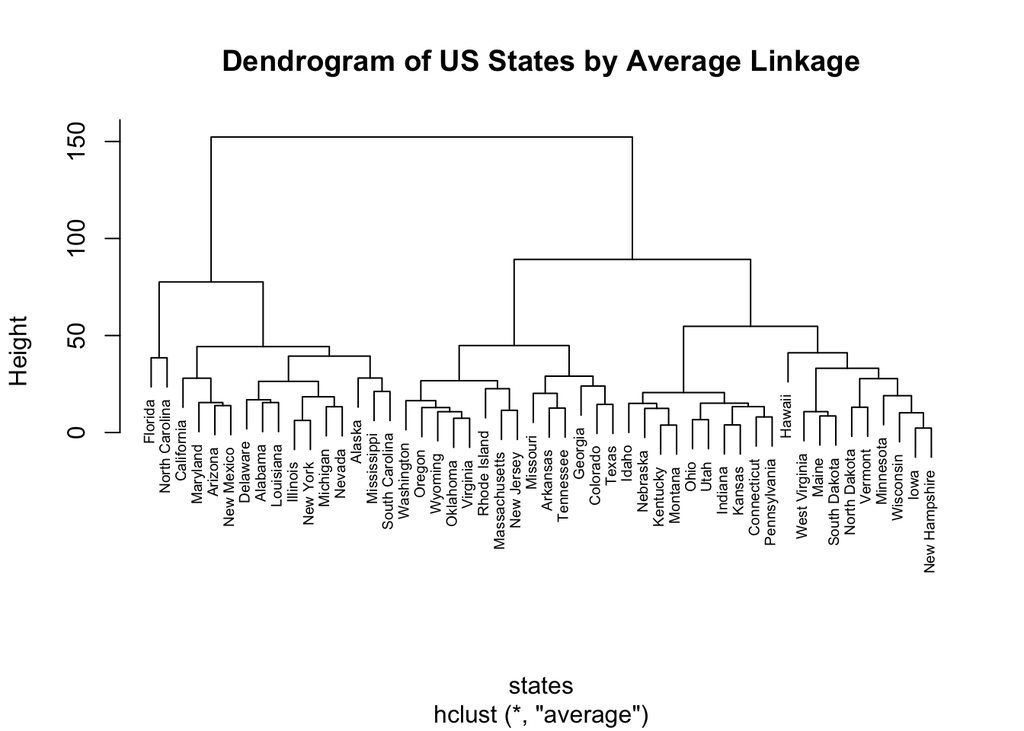

```r
#Show plots for average linkage
h_in_avg <- hclust(dist_in, method="average")
plot(h_in_avg, xlab="states",main="Dendrogram of US States by Average Linkage", cex=0.6)
```

2. Perform hierarchical clustering using complete linkage and Euclidean distance, after scaling the variables to have a standard deviation of one. Write the code and show the plots below.

```r
# Insert code here


d.in <- as.data.frame(scale(d.in))

#Euclidean distance
dist_in_scaled <- dist(d.in, method = "euclidean")

#Visualize matrix
temp_matrix <- as.matrix(dist_in_scaled)
print(temp_matrix[1:6,1:6])
```

```
##             Alabama   Alaska  Arizona Arkansas California Colorado
## Alabama    0.000000 2.703754 2.293520 1.289810   3.263110 2.651067
## Alaska     2.703754 0.000000 2.700643 2.826039   3.012541 2.326519
## Arizona    2.293520 2.700643 0.000000 2.717758   1.310484 1.365031
## Arkansas   1.289810 2.826039 2.717758 0.000000   3.763641 2.831051
## California 3.263110 3.012541 1.310484 3.763641   0.000000 1.287619
## Colorado   2.651067 2.326519 1.365031 2.831051   1.287619 0.000000
```

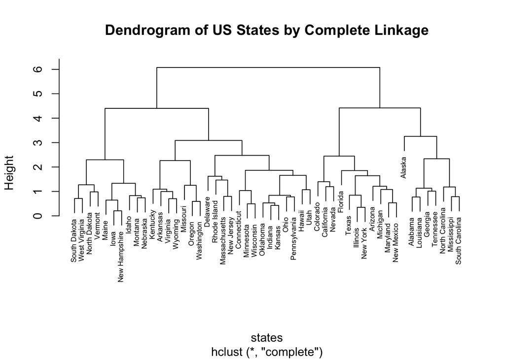

```r
#Show plots for complete linkage
h_in_complete <- hclust(dist_in_scaled, method="complete")
plot(h_in_complete, xlab="states", main = "Dendrogram of US States by Complete Linkage",cex=0.6)
```